# Diving into Kickstarter Campaign Performance

DATA501 Foundations of Data Science Using R

Kayle Megginson

12-04-2024

## ABSTRACT

The objective of this analysis was to explore Kickstarter campaigns from 2009 to 2020, focusing on campaign distribution, success rates, and factors influencing funding outcomes. I examined the number of campaigns across categories, time trends in launches, and success rates for various project types. Creative categories like Dance and Comics had the highest success rates, while Technology and Journalism struggled. A significant relationship was identified between campaign success and category, as confirmed by a chi-square test. A multiple linear regression revealed that the number of backers strongly predicts the amount pledged, with each additional backer contributing an average of $83.39. Overall, this analysis aims to show trends and key factors driving success in Kickstarter campaigns, with the goal of having this report providing valuable information for prospective creators.

## INTRODUCTION

Kickstarter is a crowdfunding platform that has revolutionized the way creators fund their projects by connecting them directly with potential backers. Since its inception in 2009, Kickstarter has hosted over half a million campaigns spanning categories such as art, technology, music, and publishing. This dataset, provided by Jonathan Leland via ICPSR, includes detailed information on campaigns launched between 2009 and 2020, capturing variables like project category, funding goals, amount pledged, backer counts, and campaign outcomes.

The dataset offers a rich opportunity to explore trends in campaign launches, assess the factors driving success, and identify areas where creators have been most successful. However, it is important to note several limitations. The dataset excludes certain identifying information (e.g., project names and URLs) to protect anonymity. Additionally, data quality issues such as missing or inconsistent values in backer counts and funding variables necessitate careful preprocessing. Despite these caveats, the dataset serves as a robust resource for understanding the dynamics of crowdfunding and deriving actionable insights for creators and researchers alike.

## DATA AND METHODOLOGY

The data examined in this analysis originates from a Kickstarter dataset encompassing campaigns launched globally from 2009 to 2020. This dataset, derived from observational study methods, includes 506,199 campaigns. Each campaign serves as an observational unit, with collected variables such as category, subcategory, state (e.g., successful, failed), funding goals, pledged amounts (in original and USD currencies), number of backers, launch dates, and deadlines. The response variable for much of the analysis is the campaign outcome (STATE), which reflects success, failure, or cancellation. Key covariates include CATEGORY, BACKERS_COUNT, and GOAL_IN_USD.

Since the data is observational, there was no random assignment of treatments or blocking. The dataset was collected passively, reflecting real-world activity on Kickstarter. The sampling scheme appears to capture all campaigns within the specified time frame rather than applying stratified or clustered sampling.

The sample size was 506199, but preprocessing was necessary to address data quality issues. Missing values in critical columns like STATE and negative values in BACKERS_COUNT were omitted to ensure valid analyses. The dataset spans over a decade, offering a comprehensive view of crowdfunding trends. However, it lacks information on external factors that might influence outcomes, representing a limitation.

## RESULTS

The analysis of Kickstarter data revealed significant insights into campaign dynamics and success factors, supported by well-labeled visualizations and statistical tests.

# Distribution of Campaigns by Category

A bar chart illustrated the number of campaigns across categories, showing that `Film & Video`, `Music`, and `Games` hosted the most campaigns, while `Dance`, `Journalism`, and `Crafts` had the fewest. This distribution suggests that certain creative and entertainment-driven categories dominate Kickstarter’s platform.

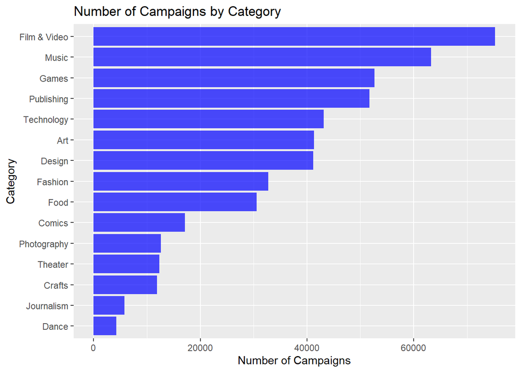

# Time Trends in Campaign Launches

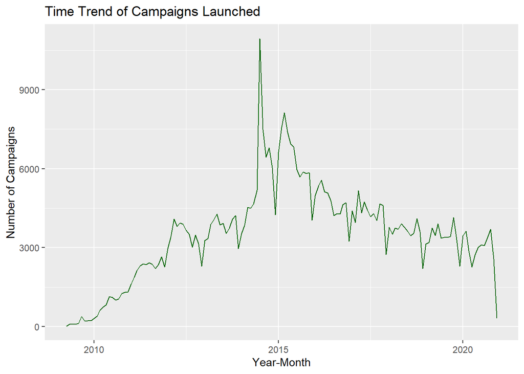

# Success Rates Across Categories

A bar chart displaying success rates by category revealed that `Dance`, `Comics`, and `Theater` had the highest success rates, exceeding 50%. Conversely, `Technology`, `Journalism`, and `Food` had the lowest success rates. These findings indicate that performance and artistic projects are more likely to resonate with backers than technology or news ventures.

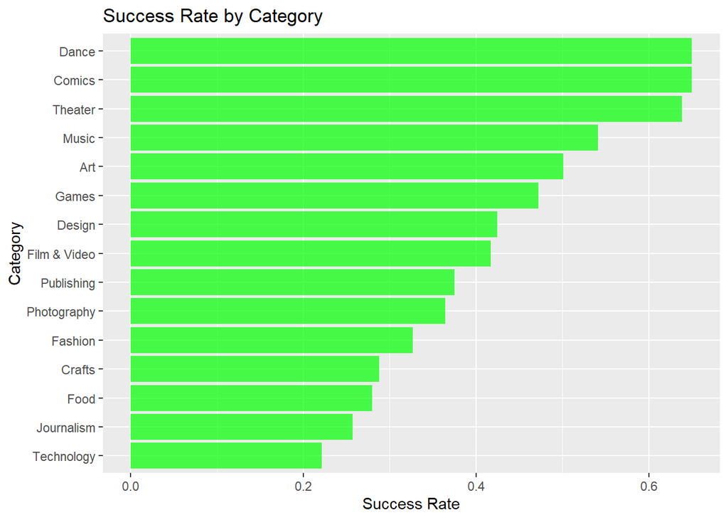

# Factors Influencing Pledged Amounts

A scatterplot with a fitted regression line depicted the relationship between `BACKERS_COUNT` and `PLEDGED_IN_USD`. A multiple linear regression analysis revealed that the number of backers significantly predicted pledged amounts, with each additional backer contributing $83.39 on average (*p* < 0.001). Additionally, higher funding goals were positively correlated with slightly higher pledged amounts, although this effect was smaller.

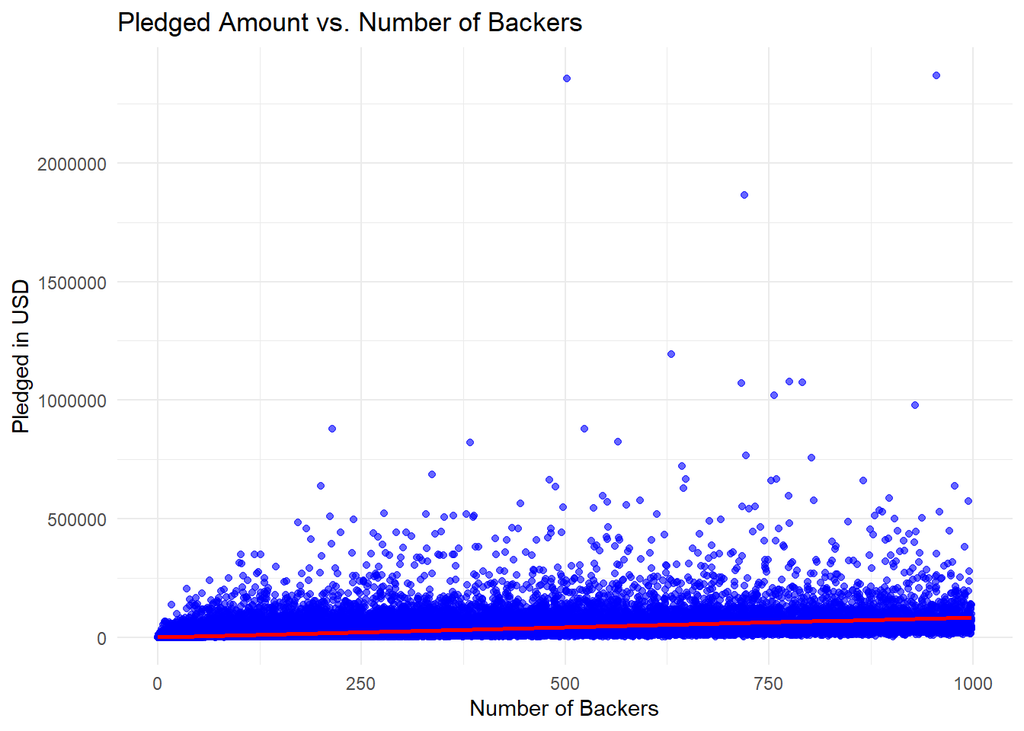

# Geographic Distribution of Campaigns

A choropleth map of the United States reveals notable geographic patterns in Kickstarter campaign origins. States with large urban centers and thriving creative industries, such as California and New York, show the highest number of campaigns, while more rural or sparsely populated states have fewer. This pattern may reflect differences in population density, cultural hubs, and regional preferences.The map provides valuable context for understanding crowdfunding activity beyond category trends and temporal dynamics.

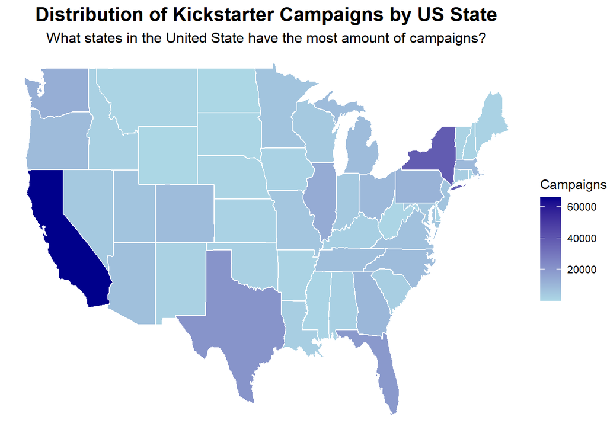

# Hypothesis Tests

- **Chi-Square Test**: A chi-square test of independence between campaign success and category was highly significant ($\chi^2$ = 29,017.63, *p* < 0.001), confirming that the likelihood of success varies significantly by category.
- **T-Test**: A t-test comparing the average number of backers for successful and failed campaigns was inconclusive due to data distribution challenges and potential outliers. Further refinement of the data would be preferable for further developments.

# Caveats

- While statistical significance was robust, practical significance should also be considered, especially given the large sample size.
- Missing external factors like marketing strategies or economic conditions limit the scope of causal interpretations.
- The dataset’s reliance on observational data means findings are correlational, not causal.

## CONCLUSION

Despite this information, the analysis has limitations. The observational nature of the dataset means that conclusions are correlational, not causal. Additionally, the absence of external variables, such as marketing efforts or economic conditions, limits the ability to fully understand the drivers of success. Data quality issues, including missing values and outliers, may also impact the robustness of some findings, such as the t-test analysis.

Future research could address these limitations by implementing more granular data, such as promotional strategies or project descriptions, to better understand what resonates with backers. Expanding the analysis to include longitudinal trends in creator behaviors or external economic factors could also provide deeper insights into crowdfunding dynamics. These additions could very well offer a better understanding of what makes campaigns successful on Kickstarter and help creators better position their projects for success.

## REFERENCES

Kickstarter dataset- Jonathan Leland via ICPSR